# Act Report

### Introduction

This report contains information about the tweeter account WeRateDogs. Composed with 2277 rows, we explored the impact on retweets and favorites over time. The stage and rating also gave us a further understanding on the trends as well.

# Analyses

### Statistics

<font size =4>Starting the analyses with statistics the below table give and overview on the rates can change. Its easy to notice a considerable wide deviation among the variables that can be further interpreted with time where can be one of the reasons due to the fact that also users or followers where increasing over time.

```python
archive_f.describe()
```

|  | tweet_id | rating | retweet_count | favorite_count |
| --- | --- | --- | --- | --- |
| count | 2.277000e+03 | 2277.000000 | 2277.000000 | 2277.000000 |
| mean | 7.420055e+17 | 10.697422 | 3242.288538 | 8229.291173 |
| std | 6.813191e+16 | 2.144986 | 5342.019848 | 11900.141552 |
| min | 6.660209e+17 | 0.000000 | 16.000000 | 0.000000 |
| 25% | 6.782786e+17 | 10.000000 | 665.000000 | 1477.000000 |
| 50% | 7.189392e+17 | 11.000000 | 1529.000000 | 3705.000000 |
| 75% | 7.986440e+17 | 12.000000 | 3732.000000 | 10414.000000 |
| max | 8.924206e+17 | 15.000000 | 79515.000000 | 132810.000000 |

### Stage

According to the chart bellow, Pupper is the most common stage followed by Doggo, Puppo and floofler respectivetly. Found interesting the fact that the sum of the stages is not the half of the Pupper stage making this stage isolate from the others in terms of the number of frequency.

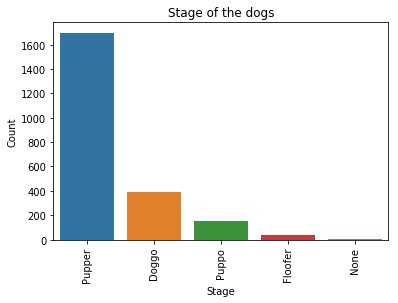

```python
visual(archive_stage,"Stage of the dogs","Stage","Count")
```

### Rating

As we could see, the rate 10 is the average, however thr the 12 its most common, the 0 rating can be the data containing wrong information letting this way 10 and 11 the second and third most rates given to the dogs

[figure not shown]

```python
visual(archive_rating,"Rating Counts", "Rating", "Count")
```

### Time

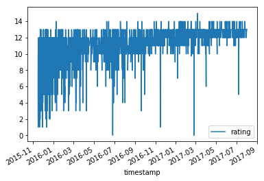

```python
archive_clean.plot(x="timestamp", y="rating")
plt.show()
```

### Retweet & Favorite

Favorite counts has cleared showed that is higher than the retweet counts, where only 2 times this situations changed letting the retweets come on top.

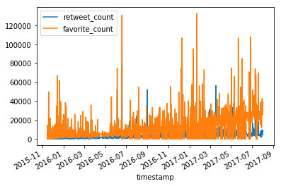

```python
archive_f.plot(x="timestamp", y=["retweet_count","favorite_count"])
plt.show()
```

Ignoring the fact that the favorites are more than retweet the trend has shown pretty much alike in both scenarions where only the peaks off retweets have almost the same number and at the same situation the pics showed to have an huge difference.

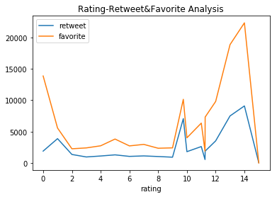

```python
rating_analyze=pd.DataFrame(columns=['rating','retweet','favorite'])
rating_analyze['rating']=values
for x in rating_analyze['rating']:
    this_df=archive_f[archive_f.rating==x]

    rating_analyze.loc[rating_analyze.rating==x,'retweet']=this_df.retweet_count.mean()
    rating_analyze.loc[rating_analyze.rating==x,'favorite']=this_df.favorite_count.mean()

rating_analyze[['rating','retweet','favorite']].plot(x='rating',title='Rating-Retweet&Favorite Analysis')
```